# AN597_Boots_mjsalnic

majo

2/11/2019

# Challenges

1. I am not sure about the code I used for the bootstrapping
2. Not sure how to interpret the β coefficients in the second question

```r
library(curl)
library(car)
f <- curl("https://raw.githubusercontent.com/fuzzyatelin/fuzzyatelin.github.io/master/AN597_Fall19/KamilarAndCooperData.csv")
d <- read.csv(f, header = TRUE, sep = ",", stringsAsFactors = FALSE)
head(d)
```

```
##               Scientific_Name          Family          Genus      Species
## 1 Allenopithecus_nigroviridis Cercopithecidae Allenopithecus nigroviridis
## 2         Allocebus_trichotis Cercopithecidae      Allocebus    trichotis
## 3           Alouatta_belzebul        Atelidae       Alouatta     belzebul
## 4             Alouatta_caraya        Atelidae       Alouatta       caraya
## 5            Alouatta_guariba        Atelidae       Alouatta      guariba
## 6           Alouatta_palliata        Atelidae       Alouatta     palliata
##   Brain_Size_Species_Mean Brain_Size_Female_Mean   Brain_size_Ref
## 1                   58.02                  53.70 Isler et al 2008
## 2                      NA                     NA
## 3                   52.84                  51.19 Isler et al 2008
## 4                   52.63                  47.80 Isler et al 2008
## 5                   51.70                  49.08 Isler et al 2008
## 6                   49.88                  48.04 Isler et al 2008
##   Body_mass_male_mean Body_mass_female_mean Mass_Dimorphism
```

[output cut: 69 more lines]

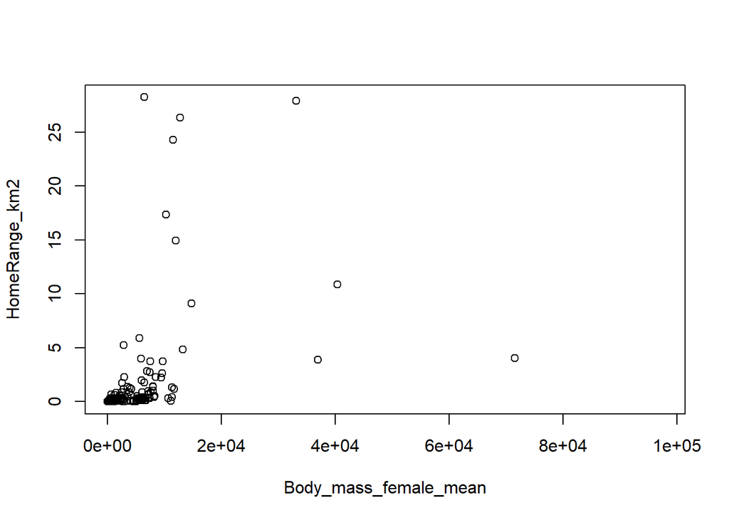

```r
plot(data = d, HomeRange_km2 ~ Body_mass_female_mean)
```

```r
model <- lm(data = d, HomeRange_km2~ Body_mass_female_mean)
summary(model)
```

```
##
## Call:
## lm(formula = HomeRange_km2 ~ Body_mass_female_mean, data = d)
##
## Residuals:
##      Min       1Q   Median       3Q      Max
## -14.0240  -1.5045  -0.6688  -0.4262  26.1404
##
## Coefficients:
##                        Estimate Std. Error t value Pr(>|t|)
## (Intercept)           5.041e-01  4.651e-01   1.084     0.28
## Body_mass_female_mean 2.454e-04  4.736e-05   5.183 7.78e-07 ***
## ---
## Signif. codes:  0 '***' 0.001 '**' 0.01 '*' 0.05 '.' 0.1 ' ' 1
##
## Residual standard error: 4.56 on 135 degrees of freedom
##   (76 observations deleted due to missingness)
## Multiple R-squared:  0.166,  Adjusted R-squared:  0.1598
## F-statistic: 26.87 on 1 and 135 DF,  p-value: 7.777e-07
```

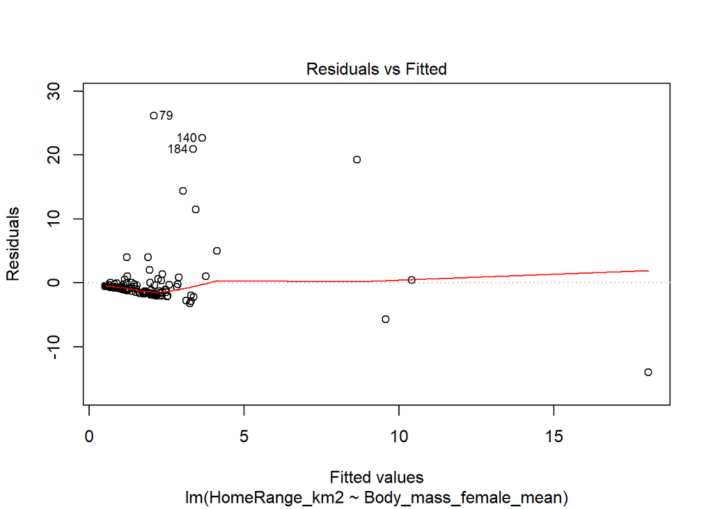

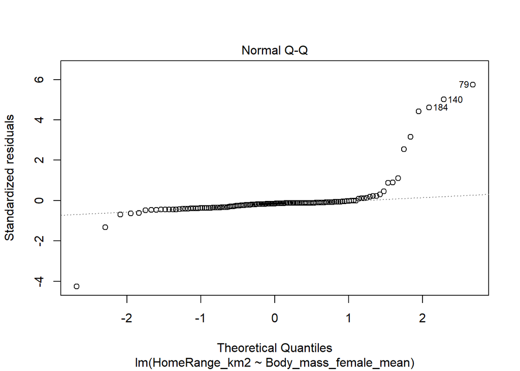

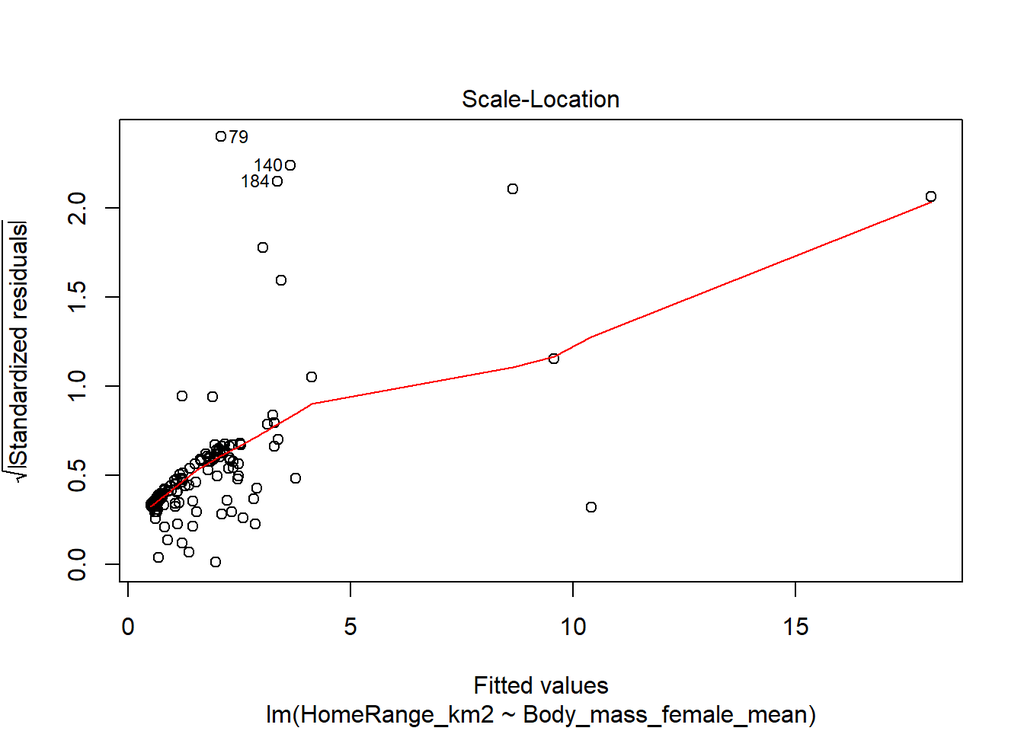

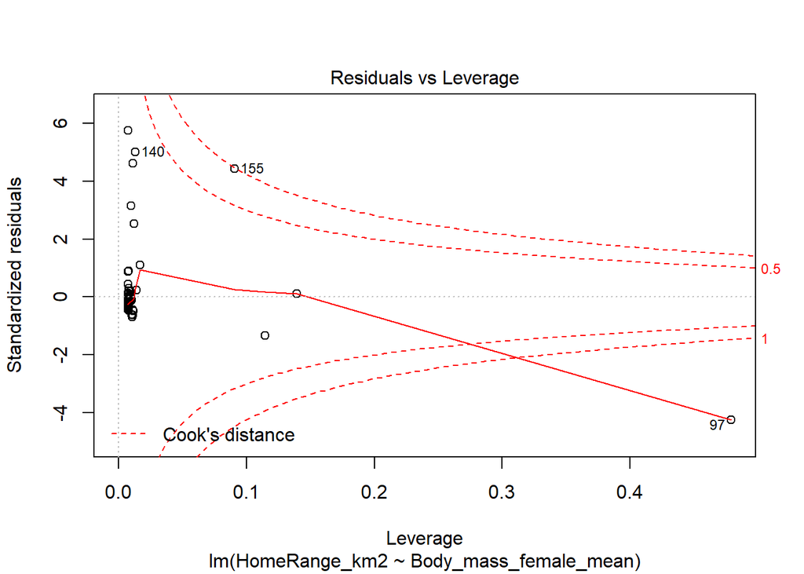

```r
plot(model)
```

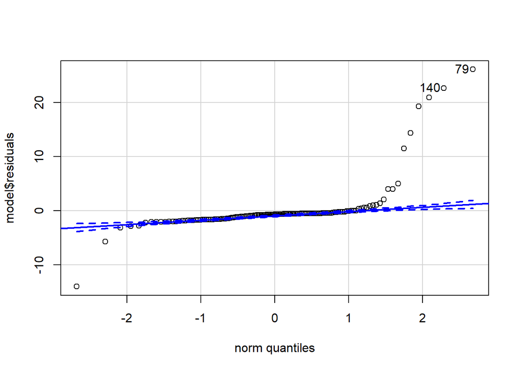

```
##  79 140
##  46  87
```

```r
qqPlot(model$residuals)
```

```r
s <- shapiro.test(model$residuals)
s
```

```
##
##  Shapiro-Wilk normality test
##
## data:  model$residuals
## W = 0.45658, p-value < 2.2e-16
```

## 1. Using the “KamilarAndCooperData.csv” dataset, run a linear regression looking at log(HomeRange_km2) in relation to log(Body_mass_female_mean) and report your β coeffiecients (slope and intercept).

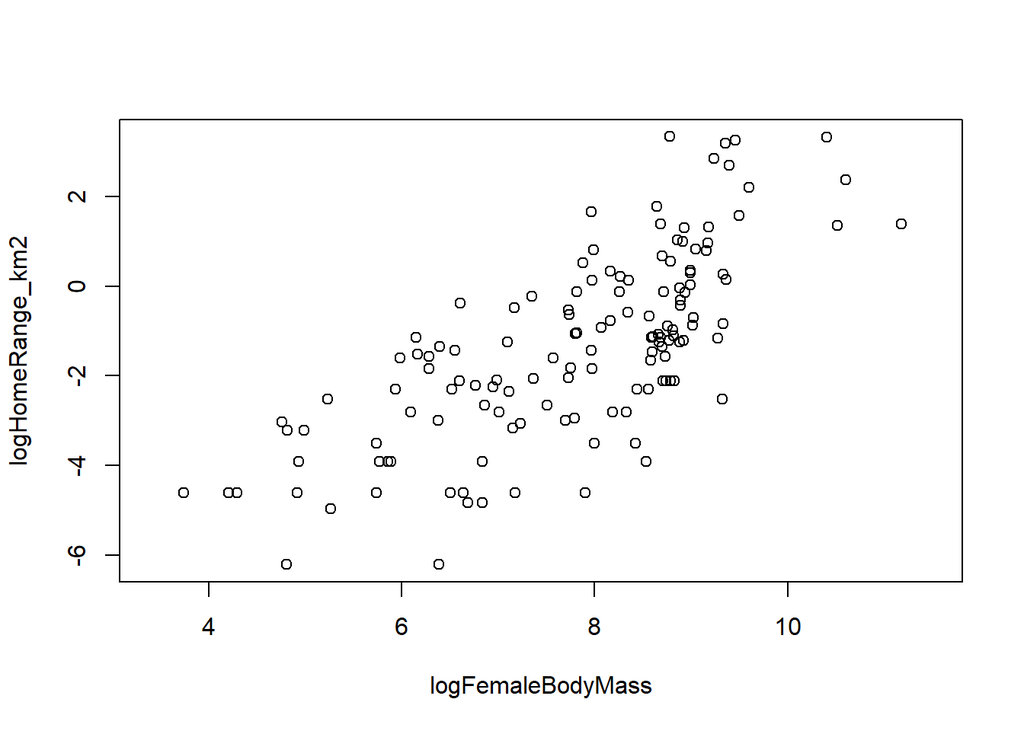

```r
d$logHomeRange_km2 <- log(d$HomeRange_km2)
d$logFemaleBodyMass <- log(d$Body_mass_female_mean)
plot(data = d, logHomeRange_km2 ~ logFemaleBodyMass)
```

```r
m <- lm(data = d, logHomeRange_km2 ~ logFemaleBodyMass)
summary(m)
```

```
##
## Call:
## lm(formula = logHomeRange_km2 ~ logFemaleBodyMass, data = d)
##
## Residuals:
##     Min      1Q  Median      3Q     Max
## -3.3929 -0.9433 -0.0126  1.0944  3.6826
##
## Coefficients:
##                   Estimate Std. Error t value Pr(>|t|)
## (Intercept)       -9.44123    0.67293  -14.03   <2e-16 ***
## logFemaleBodyMass  1.03643    0.08488   12.21   <2e-16 ***
## ---
## Signif. codes:  0 '***' 0.001 '**' 0.01 '*' 0.05 '.' 0.1 ' ' 1
##
## Residual standard error: 1.423 on 135 degrees of freedom
##   (76 observations deleted due to missingness)
## Multiple R-squared:  0.5248, Adjusted R-squared:  0.5213
## F-statistic: 149.1 on 1 and 135 DF,  p-value: < 2.2e-16
```

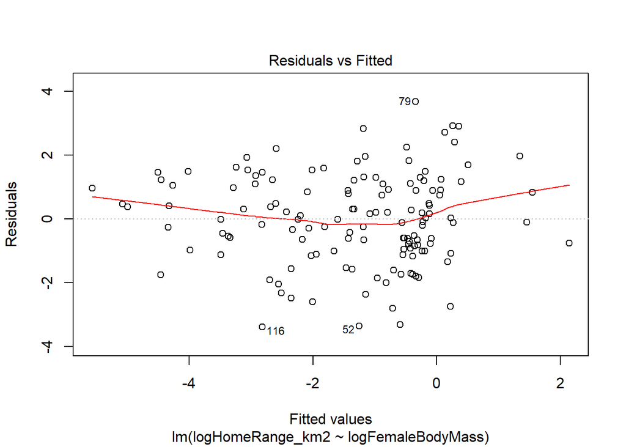

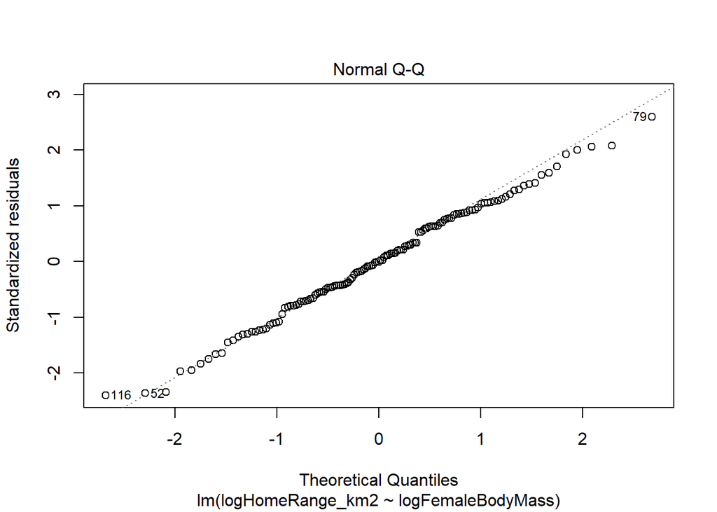

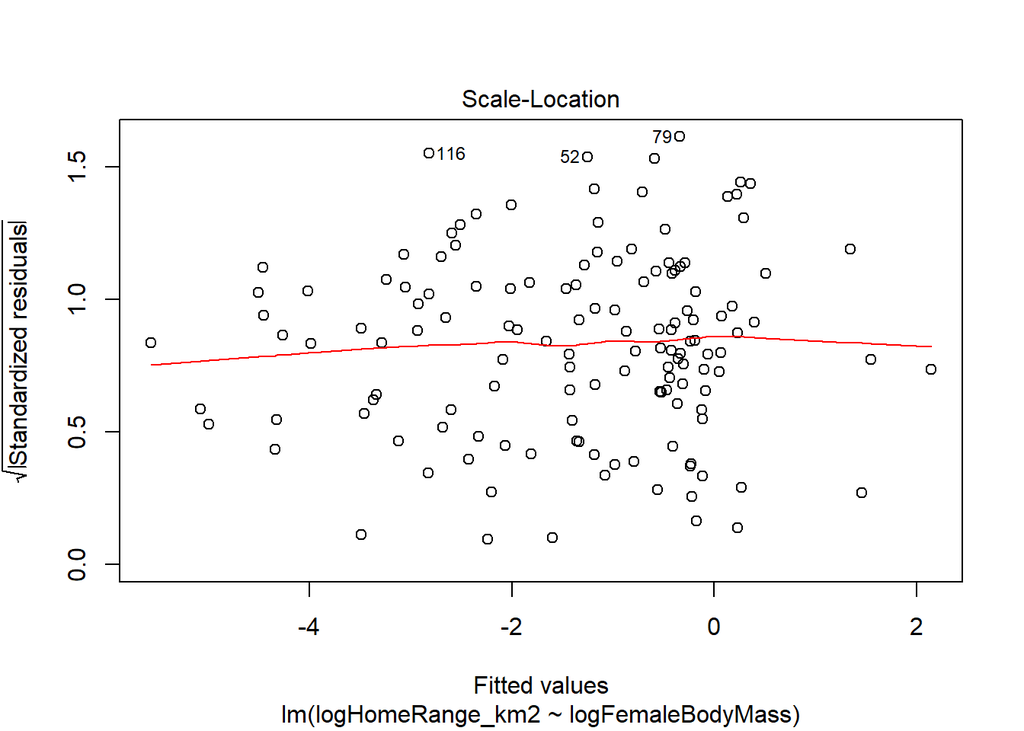

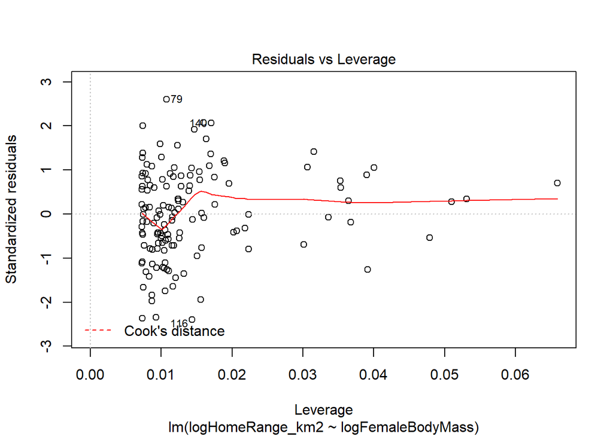

```r
plot(m)
```

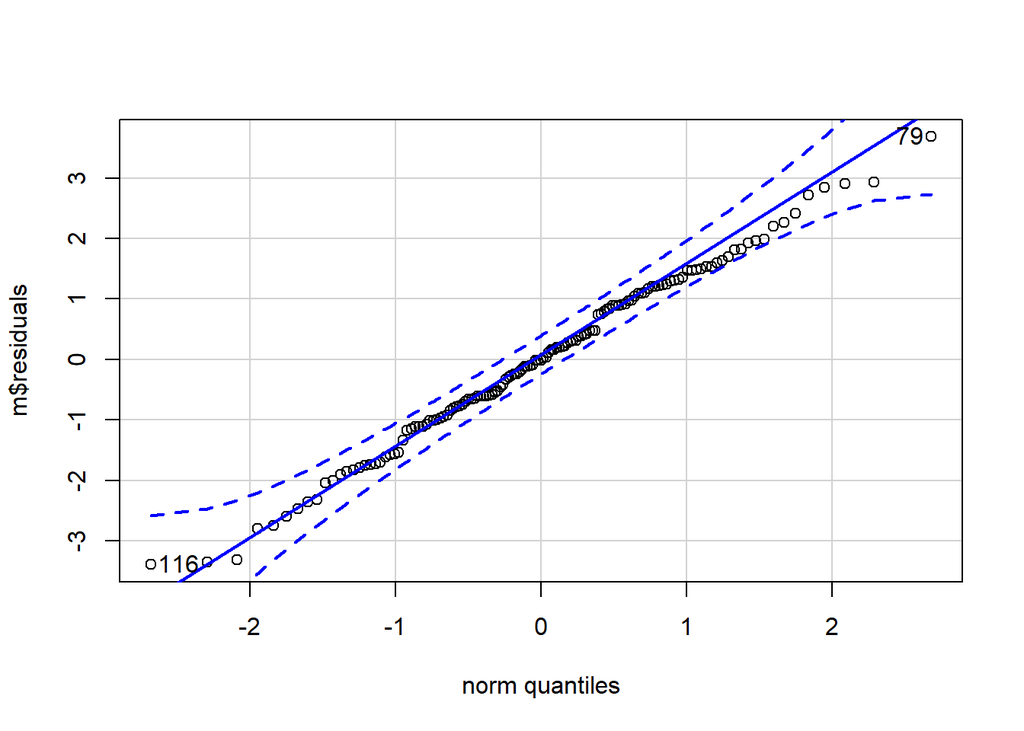

```
##  79 116
##  46  74
```

```r
qqPlot(m$residuals)
```

```r
s <- shapiro.test(m$residuals)
s
```

```
##
##  Shapiro-Wilk normality test
##
## data:  m$residuals
## W = 0.99387, p-value = 0.8258
```

```r
coefficients(m)
```

```
##       (Intercept) logFemaleBodyMass
##         -9.441231          1.036432
```

```r
confint(m, level = 0.95)
```

```
##                         2.5 %    97.5 %
## (Intercept)       -10.7720889 -8.110374
## logFemaleBodyMass   0.8685707  1.204292
```

```r
t <- coef(summary(m))
t <- data.frame(unlist(t))
colnames(t) <- c("Est", "SE", "t", "p")
t
```

```
##                         Est         SE         t            p
## (Intercept)       -9.441231 0.67293459 -14.02994 3.820677e-28
## logFemaleBodyMass  1.036432 0.08487709  12.21097 1.447292e-23
```

## 2. Then, use bootstrapping to sample from your data 1000 times with replacement, each time fitting the same model and calculating the same coefficients. This generates a sampling distribution for each β coefficient.

Estimate the standard error for each of your β coefficients as the standard deviation of the sampling distribution from your bootstrap and determine the 95% CI for each of your β coefficients based on the appropriate quantiles from your sampling distribution.

How does the former compare to the SE estimated from your entire dataset using the formula for standard error implemented in lm()?

How does the latter compare to the 95% CI estimated from your entire dataset?

```r
library(boot)
getLm<- function(dat, idx) {
  bsfit <- lm(logHomeRange_km2~logFemaleBodyMass, subset=idx, data=d)
  coef(bsfit)
}

bsReg<-boot(d, statistic = getLm, R=1000)
bsReg
```

```
##
## ORDINARY NONPARAMETRIC BOOTSTRAP
##
##
## Call:
## boot(data = d, statistic = getLm, R = 1000)
##
##
## Bootstrap Statistics :
##      original       bias    std. error
## t1* -9.441231 -0.006173005  0.61064260
## t2*  1.036432  0.001035981  0.07849211
```

```r
boot.ci(bsReg, conf = 0.95)
```

```
## BOOTSTRAP CONFIDENCE INTERVAL CALCULATIONS
## Based on 1000 bootstrap replicates
##
## CALL :
## boot.ci(boot.out = bsReg, conf = 0.95)
##
## Intervals :
## Level      Normal              Basic             Studentized
## 95%   (-10.632,  -8.238 )   (-10.654,  -8.186 )   (-10.757,  -8.290 )
##
## Level     Percentile            BCa
## 95%   (-10.696,  -8.228 )   (-10.713,  -8.306 )
## Calculations and Intervals on Original Scale
```

```r
summary(bsReg)
```

```
##
## Number of bootstrap replications R = 1000
##   original  bootBias   bootSE bootMed
## 1  -9.4412 -0.006173 0.610643 -9.4254
## 2   1.0364  0.001036 0.078492  1.0349
```

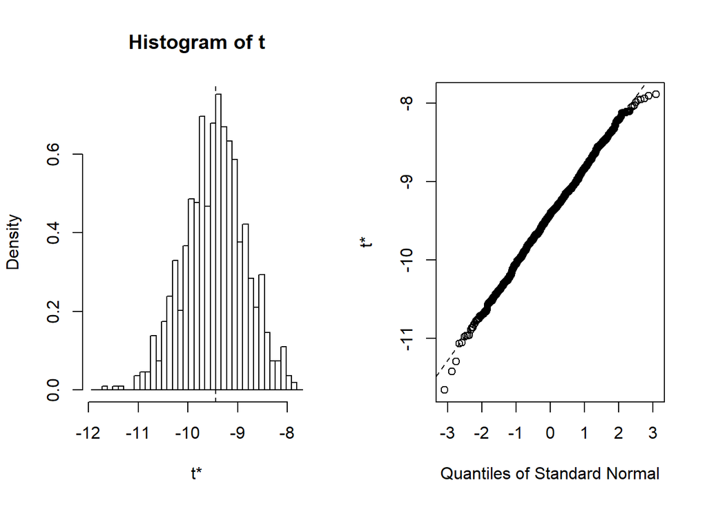

```r
plot(bsReg)
```

```r
t1 <- coef(summary(bsReg))
t1 <- data.frame(unlist(t))
colnames(t) <- c("Est", "SE", "t", "p")
t1
```

```
##          unlist.t.
## Est1 -9.441231e+00
## Est2  1.036432e+00
## SE1   6.729346e-01
## SE2   8.487709e-02
## t1   -1.402994e+01
## t2    1.221097e+01
## p1    3.820677e-28
## p2    1.447292e-23
```

```r
coefficients(bsReg)
```

```r
confint(bsReg, level = 0.95)
```

```
## Bootstrap bca confidence intervals
##
##         2.5 %    97.5 %
## 1 -10.7133404 -8.305800
## 2   0.8909331  1.198453
```

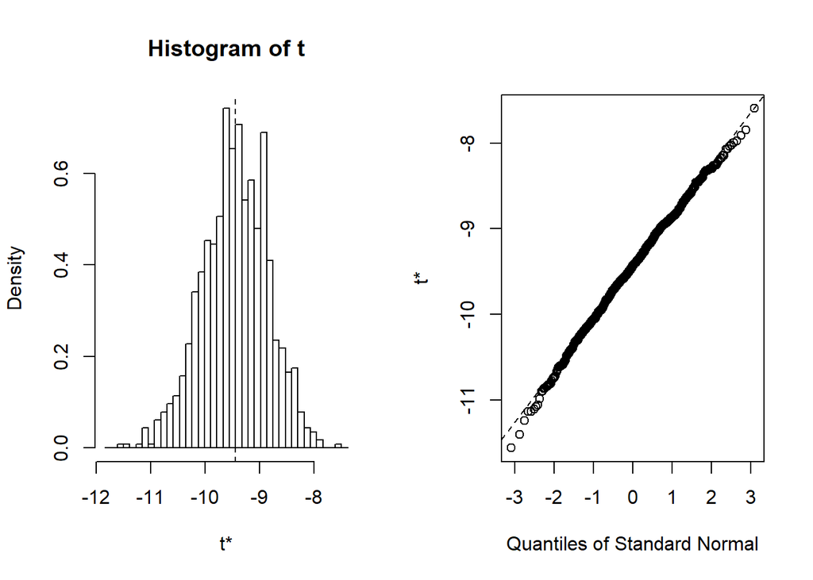

```r
bs <- function(formula, data, indices) {
  d <- data[indices,] # allows boot to select sample
  fit <- lm(formula, data=d)
  return(coef(fit))
}

results <- boot(data=d, statistic=bs,
   R=1000, formula=logHomeRange_km2~logFemaleBodyMass)

plot(results)
```

```r
boot.ci(results)
```

```
## BOOTSTRAP CONFIDENCE INTERVAL CALCULATIONS
## Based on 1000 bootstrap replicates
##
## CALL :
## boot.ci(boot.out = results)
##
## Intervals :
## Level      Normal              Basic             Studentized
## 95%   (-10.613,  -8.255 )   (-10.577,  -8.170 )   (-10.662,  -8.258 )
##
## Level     Percentile            BCa
## 95%   (-10.712,  -8.305 )   (-10.734,  -8.314 )
## Calculations and Intervals on Original Scale
```

```r
coefficients(results)
```

```r
confint(results, level = 0.95)
```

```
## Bootstrap bca confidence intervals
##
##         2.5 %    97.5 %
## 1 -10.7336531 -8.314221
## 2   0.8930567  1.201998
```